# logistic_regression_and_naive_bayes

#### 모델 성능 평가

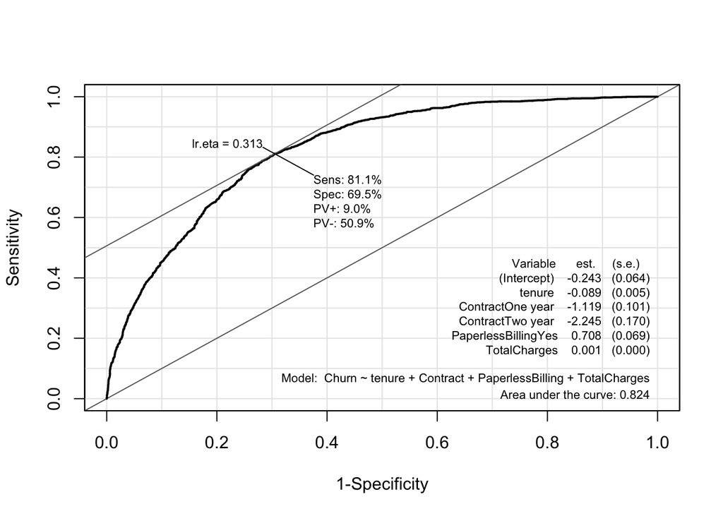

```r
graph1 = ROC(form = Churn ~ tenure + Contract + PaperlessBilling + TotalCharges, data = df, plot = 'ROC')
```

```r
graph1$res[round(graph1$res$lr.eta, 3) == 0.313,]  # 3번째 값이 가장 .313에 가깝다.
```

```
##                        sens      spec        pvp       pvn    lr.eta
## 0.312789435700227 0.8111289 0.6947511 0.08959391 0.5097025 0.3127894
## 0.312889356627246 0.8111289 0.6949448 0.08957117 0.5095438 0.3128894
## 0.312985192098337 0.8111289 0.6951385 0.08954845 0.5093851 0.3129852
## 0.313395551333727 0.8105939 0.6951385 0.08977936 0.5095500 0.3133956
## 0.313454656772414 0.8105939 0.6953322 0.08975659 0.5093912 0.3134547
```

```r
graph1$AUC   # 그래프를 적분한 값, 즉 면적 값이다. 여기서 이 값은 분류기의 정확도를 의미한다.
```

```
## [1] 0.8240617
```

```r
confusionMatrix(
  as.factor(ifelse(predict(logreg1_Modify, type = "response")>0.313,1,0)),
  as.factor(logreg1_Modify$y),
  positive = '1')
```

```
## Confusion Matrix and Statistics
##
##           Reference
## Prediction    0    1
##          0 3589  353
##          1 1574 1516
##
##                Accuracy : 0.726
##                  95% CI : (0.7154, 0.7364)
##     No Information Rate : 0.7342
##     P-Value [Acc > NIR] : 0.9425
##
##                   Kappa : 0.419
##
##  Mcnemar's Test P-Value : <2e-16
##
##             Sensitivity : 0.8111
##             Specificity : 0.6951
##          Pos Pred Value : 0.4906
##          Neg Pred Value : 0.9105
##              Prevalence : 0.2658
##          Detection Rate : 0.2156
##    Detection Prevalence : 0.4394
##       Balanced Accuracy : 0.7531
##
##        'Positive' Class : 1
##
```

```r
logreg1_Modify_F1 = 2*0.8111*0.4906 /(0.8111+0.4906)   # 0.611
logreg1_Modify_F1   # F1 값은 Sensitivity와 Pos Pred Value의 조화평균이다.
```

```
## [1] 0.6113938
```

여러 지표들을 볼수 있다. 민감도는 0.81, 특이도는 0.6951, F1값은 0.611이다. 하지만 No Information Rate에 비해 나은 것이 별로 없는 것으로 보인다. 때문에 좋은 모델이라고 할 수는 없다.

### Naive bayes classification

#### 분할

```r
# 연속형 자료를 n개의 범주형 자료로 바꿔줄 수 있는 함수를 정의한다.
mygroup = function (y,k=4){
  count = length(y)
  z = rank(y,ties.method = "min")
  return(floor((z-1)/(count/k))+1)
}

df$MonthlyCharges_group = mygroup(df$MonthlyCharges, 10)  # MonthlyCharges 값이 낮으면: 1 ~ 높으면: 10
table(df$MonthlyCharges_group)                            # 그룹이 10개로 나눠짐
```

```
##
##   1   2   3   4   5   6   7   8   9  10
## 714 702 698 699 706 709 700 704 698 702
```

```r
df$tenure_group = mygroup(df$tenure, 15)                  # tenure 값을 15개로 범주화
table(df$tenure_group)                                    # 확인
```

```
##
##   1   2   3   4   5   6   7   8   9  10  11  12  13  14  15
## 613 438 419 489 401 507 490 407 511 454 484 488 485 484 362
```

```r
df$TotalCharges_group = mygroup(df$TotalCharges, 10)      # TotalCharges 값을 10로 범주화
table(df$TotalCharges_group)                              # 확인
```

```
##
##   1   2   3   4   5   6   7   8   9  10
## 705 702 703 703 703 704 703 703 703 703
```

```r
df = df[, -c(5, 18, 19)]   # 쓸모없어진 연속형 자료를 삭제

# train, test 분할
train_idx = sample(7032, 7032*3/4)  # 샘플 생성
df_train = df[train_idx,]
df_test = df[-train_idx,]
df_train_labels = df[train_idx,]$Churn
df_test_labels = df[-train_idx,]$Churn

df_train = df_train[,-17]           # 훈련 데이터에 Churn 삭제

prop.table(table(df_train_labels))  # 테스트와 훈련 세트의 비율이 비슷한 지 확인
```

```
## df_train_labels
##         0         1
## 0.7358741 0.2641259
```

```r
prop.table(table(df_test_labels))   # 확인
```

```
## df_test_labels
##         0         1
## 0.7292378 0.2707622
```

비슷하다. 잘 나뉘어졌다. 골고루

#### 모델 생성 및 평가

```r
df_classifier = naiveBayes(df_train, df_train_labels)   # 나이브 베이즈 분류
df_test_pred = predict(df_classifier, df_test)          # 위에서 생성된 모델로 분류해 본다.
CrossTable(df_test_pred, df_test_labels,                # 크로스 테이블을 본다.
           prop.chisq = F, prop.c = F, prop.r = FALSE,
           dnn = c('predicted', 'actual'))
```

```
##    Cell Contents
## |-------------------------|
## |                       N |
## |         N / Table Total |
## |-------------------------|
##
## ==================================
##              actual
## predicted        0       1   Total
## ----------------------------------
## 0              886      86     972
##              0.504   0.049
## ----------------------------------
## 1              396     390     786
##              0.225   0.222
## ----------------------------------
## Total         1282     476    1758
## ==================================
```

```r
confusionMatrix(as.factor(df_test_pred),           # 더 깔끔하게 본다. 여러 지표를
                as.factor(df_test_labels),
                positive = '1')
```

```
## Confusion Matrix and Statistics
##
##           Reference
## Prediction   0   1
##          0 886  86
##          1 396 390
##
##                Accuracy : 0.7258
##                  95% CI : (0.7043, 0.7466)
##     No Information Rate : 0.7292
##     P-Value [Acc > NIR] : 0.6378
##
##                   Kappa : 0.4237
##
##  Mcnemar's Test P-Value : <2e-16
##
##             Sensitivity : 0.8193
##             Specificity : 0.6911
##          Pos Pred Value : 0.4962
##          Neg Pred Value : 0.9115
##              Prevalence : 0.2708
##          Detection Rate : 0.2218
##    Detection Prevalence : 0.4471
##       Balanced Accuracy : 0.7552
##
##        'Positive' Class : 1
##
```

#### 라플라스 적용

```r
df_classifier_laplace = naiveBayes(df_train, df_train_labels, laplace = 1)
df_test_pred_laplace = predict(df_classifier_laplace, df_test)

CrossTable(df_test_pred_laplace, df_test_labels,
           prop.chisq = F, prop.c = F, prop.r = FALSE,
           dnn = c('predicted', 'actual'))
```

```
##    Cell Contents
## |-------------------------|
## |                       N |
## |         N / Table Total |
## |-------------------------|
##
## ==================================
##              actual
## predicted        0       1   Total
## ----------------------------------
## 0              883      86     969
##              0.502   0.049
## ----------------------------------
## 1              399     390     789
##              0.227   0.222
## ----------------------------------
## Total         1282     476    1758
## ==================================
```

```r
confusionMatrix(as.factor(df_test_pred_laplace),
                as.factor(df_test_labels),
                positive = '1')
```

```
## Confusion Matrix and Statistics
##
##           Reference
## Prediction   0   1
##          0 883  86
##          1 399 390
##
##                Accuracy : 0.7241
##                  95% CI : (0.7026, 0.7449)
##     No Information Rate : 0.7292
##     P-Value [Acc > NIR] : 0.696
##
##                   Kappa : 0.4211
##
##  Mcnemar's Test P-Value : <2e-16
##
##             Sensitivity : 0.8193
##             Specificity : 0.6888
##          Pos Pred Value : 0.4943
##          Neg Pred Value : 0.9112
##              Prevalence : 0.2708
##          Detection Rate : 0.2218
##    Detection Prevalence : 0.4488
##       Balanced Accuracy : 0.7540
##
##        'Positive' Class : 1
##
```

# 결론

우선 로지스틱 회귀의 결과 민감도는 0.8111, 특이도는 0.6951, F1값은 0.611이다. 또한 P값은 매우 작으므로 이번 회귀분석 모델이 유의미한 결과라고 볼 수 있다. 하지만 정보가 없을 때의 기본 rate가 0.7342인데, Accuracy가 0.726인 것으로 보아 특별히 좋은 모델은 아니다.